# BayesFormula

## Bayesian Regression

### Bayes' Formula

We learn new information about certain variables or parameters of interest, like the mean return of a time series. $$ p(H|D)=\dfrac{p(H)p(D|H)}{p(D)}$$ p(H) is called *prior* probability. p(D) is the probability for the data under any hypothesis, called the *normalizing constant*. P(D|H) is the *likehood* of the data under hypothesis H. P(H|D) is the *posterior* probability after we have seen the data.

### Example:

We have two boxes, B<sub>1</sub> and B<sub>2</sub> , B<sub>1</sub> contains 20 black balls and 80 white balls, B<sub>2</sub> contains 30 black balls and 70 white balls. We randomly select a ball from one box, assuming it's black. What's the probability for the hypothesis "H1: ball is from B<sub>1</sub>" and "H2: ball is from B<sub>2</sub>".

- Prior: p(H1) = 0.5
- Normalizing constant: p(D) = 0.2*0.5 + 0.3*0.5 = 0.25
- Likehood: p(D|H1) = 0.2 Then $$p(H1|D) = \dfrac{0.5*0.2}{0.25}=0.4$$

```python
import warnings
warnings.simplefilter('ignore')
import pymc3 as pm
import numpy as np
np.random.seed(1000)
import matplotlib.pyplot as plt
%matplotlib inline
import theano.tensor as tt
```

### Introductory Example

```python
x = np.linspace(0, 10, 500)
y = 4 + 2 * x + np.random.standard_normal(len(x)) * 2
```

```python
reg = np.polyfit(x, y, 1)
  # linear regression
```

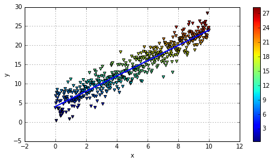

```python
plt.figure(figsize=(8, 4))
plt.scatter(x, y, c=y, marker='v')
plt.plot(x, reg[1] + reg[0] * x, lw=2.0)
plt.colorbar()
plt.grid(True)
plt.xlabel('x')
plt.ylabel('y')
# tag: pm_fig_0
# title: Sample data points a regresion line
# size: 90
```

the standard regression approach is fixed values for the parameters of the regression line.

```python
reg
```

```
array([ 1.99250739,  4.04994912])
```

### Bayesian regression

line $y=\alpha+\beta*x$

- $\alpha$ and $\beta$ are normally distributed with mean 0 and a standard deviation of 20. A majority element of Bayesian regression is (Markov Chain) Monte Carlo (MCMC) sampling.
- find_MAP finds the starting point for the sampling algorithm by deriving the cal maximum a posteriori point.
- NUTS implements the "efficient No-U-Turn Sampler with dual averaging" (NUTS) algorithm for MCMC sampling given the assumed priors.
- sample draws a number of samples given the starting value from find_MAP and the optimal step size from the NUTS algorithm.

```python
with pm.Model() as model:
        # model specifications in PyMC3
        # are wrapped in a with-statement
    # define priors
    alpha = pm.Normal('alpha', mu=0, sd=20)
    beta = pm.Normal('beta', mu=0, sd=20)
    sigma = pm.Uniform('sigma', lower=0, upper=10)

    # define linear regression
    y_est = alpha + beta * x

    # define likelihood
    likelihood = pm.Normal('y', mu=y_est, sd=sigma, observed=y)

    # inference
    start = pm.find_MAP()
      # find starting value by optimization
    step = pm.NUTS(state=start)
      # instantiate MCMC sampling algorithm
    trace = pm.sample(100, step, start=start, progressbar=False)
      # draw 100 posterior samples using NUTS sampling
```

```
Optimization terminated successfully.
         Current function value: 1064.240956
         Iterations: 16
         Function evaluations: 23
         Gradient evaluations: 23
```

```python
trace[0]
```

```
{'alpha': 4.0250633878020832,
 'beta': 1.9990752480983811,
 'sigma': 1.951416087440917,
 'sigma_interval_': -1.4169408567642627}
```

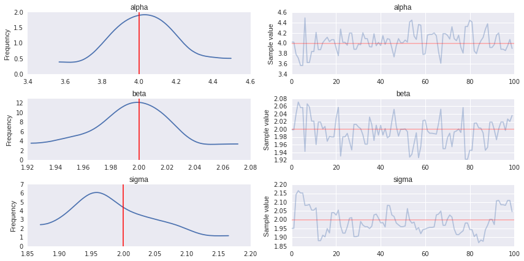

```python
fig = pm.traceplot(trace, lines={'alpha': 4, 'beta': 2, 'sigma': 2})
plt.figure(figsize=(8, 8))
# tag: pm_fig_1
# title: Trace plots for alpha, beta and sigma
# size: 90
```

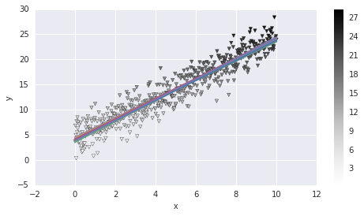

```python
plt.figure(figsize=(8, 4))
plt.scatter(x, y, c=y, marker='v')
plt.colorbar()
plt.grid(True)
plt.xlabel('x')
plt.ylabel('y')
for i in range(len(trace)):
    plt.plot(x, trace['alpha'][i] + trace['beta'][i] * x)
# tag: pm_fig_2
# title: Sample data and regression lines from Bayesian regression
# size: 90
```